# Heart Failure Prediction

### Pušenje

```r
length(which(is.na(data$smoking)))
```

```
[1] 1
```

```r
data[which(is.na(data$smoking)),]
```

|  | age | anaemia | creatinine_phosphokinase | diabetes | ejection_fraction | high_blood_pressure | platelets | serum_creatinine | serum_sodium | sex | smoking | time | DEATH_EVENT | anaemia_cat | diabetes_cat | high_blood_pressure_cat | sex_cat | smoking_cat | DEATH_EVENT_cat | age_cat |
| --- | --- | --- | --- | --- | --- | --- | --- | --- | --- | --- | --- | --- | --- | --- | --- | --- | --- | --- | --- | --- |
| 301 | 60 | 0 | 146 | 0 | 20 | 0 | 162000 | 1.3 | 129 | 1 | NA | 7 | 1 | Nema anemiju | Nema dijabetes | Nema povišen krvni pritisak | M | NA | Preminuo | 51-65 |

```r
xtabs(~smoking_cat, data=data[data$sex==1,])
```

```
smoking_cat
 Ne  Da
108  95
```

Najbrojniji u skupu su nepušači. Ovom tehnikom bi ispitanik bio nepušač.

Zahvaljujući domenskom znanju, znamo da pušenje može da utiče na broj trombocita u krvi, nivo kreatinina u krvi, pritisak i pojavu dijabetesa. Navedene parametre ćemo posmatrati kako bi odredili da li je ispitanik pušač ili ne.

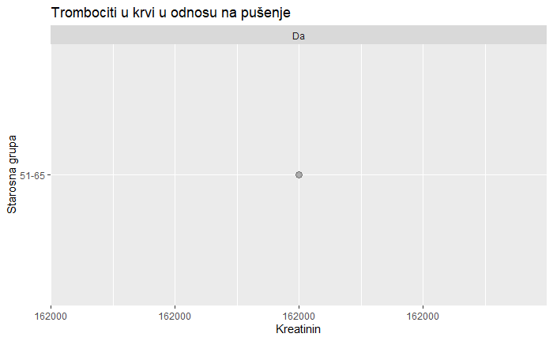

```r
platelets_smoking=data[which(data$age_cat=="51-65" & !is.na(data$smoking) & data$platelets>=157000 & data$platelets<=167000 & data$sex_cat=="M"),]
ggplot(platelets_smoking, aes(x = platelets, y=age_cat)) +
  geom_point(size = 3, alpha = 0.3)+
  facet_wrap(~smoking_cat,nrow = 2)+
  labs(title = "Trombociti u krvi u odnosu na pušenje", x = "Kreatinin", y = "Starosna grupa")
```

Imamo samo jednog najbližeg suseda i prema tome bi ispitanik od interesa se klasifikovao kao pušač. Da pogledamo kakva će situacija biti ako uvećamo prečnik kruga koji posmatramo.

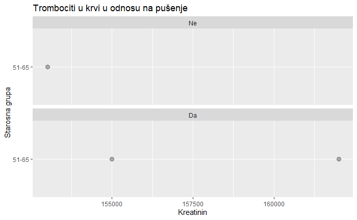

```r
platelets_smoking2=data[which(data$age_cat=="51-65" & !is.na(data$smoking) & data$platelets>=152000 & data$platelets<=172000 & data$sex_cat=="M"),]
ggplot(platelets_smoking2, aes(x = platelets, y=age_cat)) +
  geom_point(size = 3, alpha = 0.3)+
  facet_wrap(~smoking_cat,nrow = 2)+
  labs(title = "Trombociti u krvi u odnosu na pušenje", x = "Kreatinin", y = "Starosna grupa")
```

Vidimo da je situacija gotovo identična.

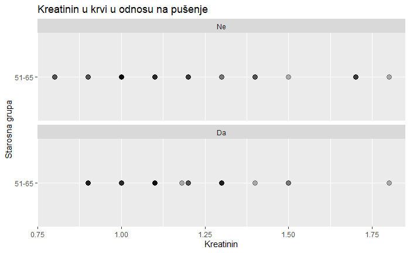

```r
creatinine_smoking=data[which(data$age_cat=="51-65" & !is.na(data$smoking) & data$serum_creatinine>=0.8 & data$serum_creatinine<=1.8 & data$sex_cat=="M"),]
ggplot(creatinine_smoking, aes(x = serum_creatinine, y=age_cat)) +
  geom_point(size = 3, alpha = 0.3)+
  facet_wrap(~smoking_cat,nrow = 2)+
  labs(title = "Kreatinin u krvi u odnosu na pušenje", x = "Kreatinin", y = "Starosna grupa")
```

```r
xtabs(~smoking_cat, data=creatinine_smoking)
```

```
smoking_cat
Ne Da
35 33
```

Za parametar kreatinin imamo više nepušača.

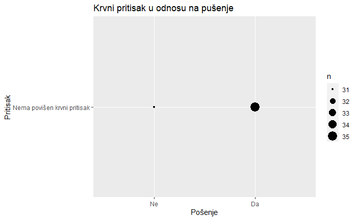

```r
hbps=data[which(data$age_cat=="51-65" & !is.na(data$smoking) & data$high_blood_pressure==0 & data$sex_cat=="M"),]
ggplot(hbps) +
  geom_count(mapping = aes(x=smoking_cat,y=high_blood_pressure_cat))+
  labs(title = "Krvni pritisak u odnosu na pušenje", x = "Pošenje", y = "Pritisak")
```

Sa grafika vidimo da je ispitivač najverovatnije pušač.

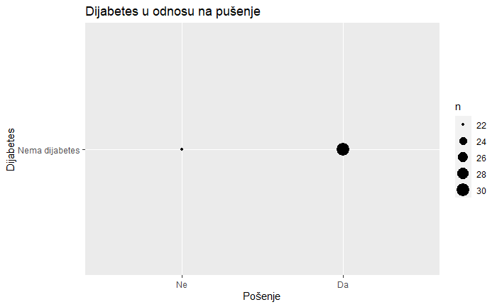

```r
ds=data[which(data$age_cat=="51-65" & !is.na(data$smoking) & data$diabetes==0 & data$sex_cat=="M"),]
ggplot(ds) +
  geom_count(mapping = aes(x=smoking_cat,y=diabetes_cat))+
  labs(title = "Dijabetes u odnosu na pušenje", x = "Pošenje", y = "Dijabetes")
```

Sa ovog grafika se takodje vidi da je ispitanik najverovatnije pušač.

Na osnovu rezultata prethodnih grafika možemo zaključiti da je ispitanik najverovatnije pušač.

```r
data$smoking[301]=1
data$smoking_cat[301]="Da"
```

```r
data[301,]
```

|  | age | anaemia | creatinine_phosphokinase | diabetes | ejection_fraction | high_blood_pressure | platelets | serum_creatinine | serum_sodium | sex | smoking | time | DEATH_EVENT | anaemia_cat | diabetes_cat | high_blood_pressure_cat | sex_cat | smoking_cat | DEATH_EVENT_cat | age_cat |
| --- | --- | --- | --- | --- | --- | --- | --- | --- | --- | --- | --- | --- | --- | --- | --- | --- | --- | --- | --- | --- |
| 301 | 60 | 0 | 146 | 0 | 20 | 0 | 162000 | 1.3 | 129 | 1 | 1 | 7 | 1 | Nema anemiju | Nema dijabetes | Nema povišen krvni pritisak | M | Da | Preminuo | 51-65 |

## Numeričke promenljive sa malim brojem nedostajućih vrednosti

### Starost

Nedostajuće vrednosti za starost ispitanika:

```r
length(which(is.na(data$age)))
```

```
[1] 1
```

Možemo primetiti da imamo samo jednu nedostajuću vrednost, pa ćemo je pogledati:

```r
data[which(is.na(data$age)),1:13]
```

|  | age | anaemia | creatinine_phosphokinase | diabetes | ejection_fraction | high_blood_pressure | platelets | serum_creatinine | serum_sodium | sex | smoking | time | DEATH_EVENT |
| --- | --- | --- | --- | --- | --- | --- | --- | --- | --- | --- | --- | --- | --- |
| 306 | NA | 0 | 582 | 1 | 55 | 0 | 147000 | 1.2 | 141 | 1 | 0 | 25 | 0 |

Jedna od opcija je da samo uzmemo prosečnu vrednost godina svih ispitanika i njome zamenimo nedostajuću vrednost, jer kako je samo jedan red u pitanju, to neće imati bitan uticaj na nastavak rada sa skupom. Međutim, postoji bolji način. Kako znamo da broj trombocita u krvi zavisi od životnog doba i pola, možemo na osnovu poznatog pola i broja trombocita odrediti nepoznate godine ispitanika. Na broj trombocita, na osnovu domenskog znanja utiče i anemija, ali kako iz prikaza vidimo da ispitanik nema anemiju, možemo slobodno da se oslonimo na pol i trombocite. Vidimo da je osoba muškog pola i da ima 147000 trombocita u krvi.

Kako bismo što preciznije odredili broj godina ispitanika, pronaći ćemo u skupu ispitanike koji su takođe muškog pola, koji nemaju anemiju i koji imaju sličan broj trombocita (±5000), a potom uzeti prosečnu vrednost njihovih godina.

```r
similar_respondents=data[which(data$sex==1 & !is.na(data$age) & data$anaemia==0 & data$platelets>=142000 & data$platelets<=152000),]
```

Pogledajmo ispitanike koji su slični posmatranom.

```r
similar_respondents
```

|  | age | anaemia | creatinine_phosphokinase | diabetes | ejection_fraction | high_blood_pressure | platelets | serum_creatinine | serum_sodium | sex | smoking | time | DEATH_EVENT | anaemia_cat | diabetes_cat | high_blood_pressure_cat | sex_cat | smoking_cat | DEATH_EVENT_cat | age_cat |
| --- | --- | --- | --- | --- | --- | --- | --- | --- | --- | --- | --- | --- | --- | --- | --- | --- | --- | --- | --- | --- |
| 26 | 80 | 0 | 148 | 1 | 38 | 0 | 149000 | 1.9 | 144 | 1 | 1 | 23 | 1 | Nema anemiju | Ima dijabetes | Nema povišen krvni pritisak | M | Da | Preminuo | 75+ |
| 74 | 65 | 0 | 224 | 1 | 50 | 0 | 149000 | 1.3 | 137 | 1 | 1 | 72 | 0 | Nema anemiju | Ima dijabetes | Nema povišen krvni pritisak | M | Da | Nije preminuo | 51-65 |
| 103 | 80 | 0 | 898 | 0 | 25 | 0 | 149000 | 1.1 | 144 | 1 | 1 | 87 | 0 | Nema anemiju | Nema dijabetes | Nema povišen krvni pritisak | M | Da | Nije preminuo | 75+ |
| 212 | 50 | 0 | 582 | 0 | 62 | 1 | 147000 | 0.8 | 140 | 1 | 1 | 192 | 0 | Nema anemiju | Nema dijabetes | Ima povišen krvni pritisak | M | Da | Nije preminuo | 40-50 |
| 265 | 61 | 0 | 582 | 1 | 38 | 0 | 147000 | 1.2 | 141 | 1 | 0 | 237 | 0 | Nema anemiju | Ima dijabetes | Nema povišen krvni pritisak | M | Ne | Nije preminuo | 51-65 |
| 313 | 65 | 0 | NA | 1 | 50 | 0 | 149000 | 1.3 | 137 | 1 | 1 | 72 | 0 | Nema anemiju | Ima dijabetes | Nema povišen krvni pritisak | M | Da | Nije preminuo | 51-65 |

Pronašli smo 6 ispitanika. Proverićemo prvo distribuciju podataka.

```r
shapiro.test(similar_respondents$age)
```

```
    Shapiro-Wilk normality test

data:  similar_respondents$age
W = 0.90377, p-value = 0.3967
```

P-value je veće od 0.05, na osnovu čega znamo da za pronalaženje prosečne vrednosti nećemo koristiti median, već mean funkciju. Prosečna vrednost godina ispitanika sa sličnim osobinama iznosi:

```r
as.integer(mean(similar_respondents$age))
```

```
[1] 66
```

```r
brGodina = as.integer(mean(similar_respondents$age))
```

Dobili smo prosečan broj godina - 66. Zamenićemo NA sa ovom vrednošću:

```r
data$age[is.na(data$age)] = brGodina
```

Provera da li smo uspešno upisali broj godina:

```r
length(which(is.na(data$age)))
```

```
[1] 0
```

Vidimo da je sada broj nedostajućih vrednosti 0 u ovoj koloni, dodatno u skladu sa ovim zaključkom treba zameniti i nedostajuću vrednost koja postoji u koloni age_cat.

```r
length(which(is.na(data$age_cat)))
```

```
[1] 1
```

```r
data$age_cat[is.na(data$age_cat)] = "66-75"
```

Provera:

```r
length(which(is.na(data$age_cat)))
```

```
[1] 0
```

### CPK enzim u krvi

Nedostajuće vrednosti za kreatin kinazu:

```r
length(which(is.na(data$creatinine_phosphokinase)))
```

```
[1] 2
```

Nedostaju nam vrednosti CPK enzima za dva ispitanika, pogledajmo te redove:

```r
data[which(is.na(data$creatinine_phosphokinase)),1:13]
```

|  | age | anaemia | creatinine_phosphokinase | diabetes | ejection_fraction | high_blood_pressure | platelets | serum_creatinine | serum_sodium | sex | smoking | time | DEATH_EVENT |
| --- | --- | --- | --- | --- | --- | --- | --- | --- | --- | --- | --- | --- | --- |
| 310 | 40 | 0 | NA | 1 | 38 | 1 | 263358 | NA | 137 | 0 | 0 | 185 | 0 |
| 313 | 65 | 0 | NA | 1 | 50 | 0 | 149000 | 1.3 | 137 | 1 | 1 | 72 | 0 |

```r
which(is.na(data$creatinine_phosphokinase))
```

```
[1] 308 311
```

Pošto znamo da količina ovog enzima u krvi zavisi od starosti i pola, pokušaćemo da pronađemo ispitanike koji imaju isti pol i pripadaju istoj starosnoj grupi za svakog od ova dva ispitanika.

**Prvi ispitanik**  
Prvi ispitanik je ženskog pola i ima 40 godina. Potražićemo osobe sa 40-50 godina koje su ženskog pola. Takođe, kako u skupu imamo i vrlo visoke vrednosti CPK enzima koje su moguće ali najčešće ukazuju na neku povredu, izuzećemo ispitanike kod kojih je CPK previsok (>= 5000 mcg/L).

```r
f_40_50=data[which(data$sex==0 & data$age_cat=="40-50" & data$creatinine_phosphokinase<=5000 & !is.na(data$creatinine_phosphokinase)),]
f_40_50
```

|  | age | anaemia | creatinine_phosphokinase | diabetes | ejection_fraction | high_blood_pressure | platelets | serum_creatinine | serum_sodium | sex | smoking | time | DEATH_EVENT | anaemia_cat | diabetes_cat | high_blood_pressure_cat | sex_cat | smoking_cat | DEATH_EVENT_cat | age_cat |
| --- | --- | --- | --- | --- | --- | --- | --- | --- | --- | --- | --- | --- | --- | --- | --- | --- | --- | --- | --- | --- |
| 15 | 49 | 1 | 80 | 0 | 30 | 1 | 427000 | 1.00 | 138 | 0 | 0 | 12 | 0 | Ima anemiju | Nema dijabetes | Ima povišen krvni pritisak | Ž | Ne | Nije preminuo | 40-50 |
| 20 | 48 | 1 | 582 | 1 | 55 | 0 | 87000 | 1.90 | 121 | 0 | 0 | 15 | 1 | Ima anemiju | Ima dijabetes | Nema povišen krvni pritisak | Ž | Ne | Preminuo | 40-50 |
| 33 | 50 | 1 | 249 | 1 | 35 | 1 | 319000 | 1.00 | 128 | 0 | 0 | 28 | 1 | Ima anemiju | Ima dijabetes | Ima povišen krvni pritisak | Ž | Ne | Preminuo | 40-50 |
| 34 | 50 | 1 | 159 | 1 | 30 | 0 | 302000 | 1.20 | 138 | 0 | 0 | 29 | 0 | Ima anemiju | Ima dijabetes | Nema povišen krvni pritisak | Ž | Ne | Nije preminuo | 40-50 |
| 42 | 50 | 0 | 124 | 1 | 30 | 1 | 153000 | 1.20 | 136 | 0 | 1 | 32 | 1 | Nema anemiju | Ima dijabetes | Ima povišen krvni pritisak | Ž | Da | Preminuo | 40-50 |
| 62 | 50 | 0 | 318 | 0 | 40 | 1 | 216000 | 2.30 | 131 | 0 | 0 | 60 | 1 | Nema anemiju | Nema dijabetes | Ima povišen krvni pritisak | Ž | Ne | Preminuo | 40-50 |
| 65 | 45 | 0 | 582 | 0 | 80 | 0 | 263358 | 1.18 | 137 | 0 | 0 | 63 | 0 | Nema anemiju | Nema dijabetes | Nema povišen krvni pritisak | Ž | Ne | Nije preminuo | 40-50 |
| 67 | 42 | 1 | 250 | 1 | 15 | 0 | 213000 | 1.30 | 136 | 0 | 0 | 65 | 1 | Ima anemiju | Ima dijabetes | Nema povišen krvni pritisak | Ž | Ne | Preminuo | 40-50 |
| 93 | 42 | 0 | 582 | 0 | 60 | 0 | 263358 | 1.18 | 137 | 0 | 0 | 82 | 0 | Nema anemiju | Nema dijabetes | Nema povišen krvni pritisak | Ž | Ne | Nije preminuo | 40-50 |
| 126 | 43 | 1 | 358 | 0 | 50 | 0 | 237000 | 1.30 | 135 | 0 | 0 | 97 | 0 | Ima anemiju | Nema dijabetes | Nema povišen krvni pritisak | Ž | Ne | Nije preminuo | 40-50 |

[output cut: 21 more lines]

Iskoristićemo Šapirov test da proverimo distribuciju podataka, na osnovu čega ćemo znati da li treba da iskoristimo mean ili median za prosečnu vrednost koju tražimo.

```r
shapiro.test(f_40_50$creatinine_phosphokinase)
```

```
    Shapiro-Wilk normality test

data:  f_40_50$creatinine_phosphokinase
W = 0.70852, p-value = 1.556e-06
```

P-value je znatno manje od 0.05, što nam govori da nemamo normalnu distribuciju podataka i da treba da koristimo median. U suprotnom bismo koristili mean.

Izračunaćemo prosečnu vrednost kreatin kinaze od prikazanih 31 ispitanika, i nedostajuću vrednost zameniti njom.

```r
as.integer(median(f_40_50$creatinine_phosphokinase))
```

```
[1] 582
```

```r
meanCPK = as.integer(median(f_40_50$creatinine_phosphokinase))
```

```r
data$creatinine_phosphokinase[which(data$sex==0 & is.na(data$creatinine_phosphokinase))] = meanCPK
data[308,]
```

|  | age | anaemia | creatinine_phosphokinase | diabetes | ejection_fraction | high_blood_pressure | platelets | serum_creatinine | serum_sodium | sex | smoking | time | DEATH_EVENT | anaemia_cat | diabetes_cat | high_blood_pressure_cat | sex_cat | smoking_cat | DEATH_EVENT_cat | age_cat |
| --- | --- | --- | --- | --- | --- | --- | --- | --- | --- | --- | --- | --- | --- | --- | --- | --- | --- | --- | --- | --- |
| 310 | 40 | 0 | 582 | 1 | 38 | 1 | 263358 | NA | 137 | 0 | 0 | 185 | 0 | Nema anemiju | Ima dijabetes | Ima povišen krvni pritisak | Ž | Ne | Nije preminuo | 40-50 |

Vidimo da smo uspešno popunili nedostajuću vrednost, i sada bi trebalo da nam je ostala još samo jedna.

```r
length(which(is.na(data$creatinine_phosphokinase)))
```

```
[1] 1
```

Preostalu nedostajuću vrednost odredićemo na sličan način.

**Drugi ispitanik**  
Drugi ispitanik je muškog pola i ima 65 godina. Potražićemo osobe sa 51-65 godina koje su muškog pola. Kao i u prethodnom slučaju, izuzećemo ispitanike kod kojih je CPK previsok (>= 5000 mcg/L).

```r
m_51_65=data[which(data$sex==1 & data$age_cat=="51-65" & data$creatinine_phosphokinase<=5000 & !is.na(data$creatinine_phosphokinase)),]
m_51_65
```

|  | age | anaemia | creatinine_phosphokinase | diabetes | ejection_fraction | high_blood_pressure | platelets | serum_creatinine | serum_sodium | sex | smoking | time | DEATH_EVENT | anaemia_cat | diabetes_cat | high_blood_pressure_cat | sex_cat | smoking_cat | DEATH_EVENT_cat | age_cat |
| --- | --- | --- | --- | --- | --- | --- | --- | --- | --- | --- | --- | --- | --- | --- | --- | --- | --- | --- | --- | --- |
| 3 | 65 | 0 | 146 | 0 | 20 | 0 | 162000 | 1.30 | 129 | 1 | 1 | 7 | 1 | Nema anemiju | Nema dijabetes | Nema povišen krvni pritisak | M | Da | Preminuo | 51-65 |
| 8 | 60 | 1 | 315 | 1 | 60 | 0 | 454000 | 1.10 | 131 | 1 | 1 | 10 | 1 | Ima anemiju | Ima dijabetes | Nema povišen krvni pritisak | M | Da | Preminuo | 51-65 |
| 12 | 62 | 0 | 231 | 0 | 25 | 1 | 253000 | 0.90 | 140 | 1 | 1 | 10 | 1 | Nema anemiju | Nema dijabetes | Ima povišen krvni pritisak | M | Da | Preminuo | 51-65 |
| 24 | 53 | 0 | 63 | 1 | 60 | 0 | 368000 | 0.80 | 135 | 1 | 0 | 22 | 0 | Nema anemiju | Ima dijabetes | Nema povišen krvni pritisak | M | Ne | Nije preminuo | 51-65 |
| 29 | 58 | 1 | 60 | 0 | 38 | 0 | 153000 | 5.80 | 134 | 1 | 0 | 26 | 1 | Ima anemiju | Nema dijabetes | Nema povišen krvni pritisak | M | Ne | Preminuo | 51-65 |
| 35 | 65 | 0 | 94 | 1 | 50 | 1 | 188000 | 1.00 | 140 | 1 | 0 | 29 | 1 | Nema anemiju | Ima dijabetes | Ima povišen krvni pritisak | M | Ne | Preminuo | 51-65 |
| 39 | 60 | 0 | 2656 | 1 | 30 | 0 | 305000 | 2.30 | 137 | 1 | 0 | 30 | 0 | Nema anemiju | Ima dijabetes | Nema povišen krvni pritisak | M | Ne | Nije preminuo | 51-65 |
| 47 | 51 | 0 | 1380 | 0 | 25 | 1 | 271000 | 0.90 | 130 | 1 | 0 | 38 | 1 | Nema anemiju | Nema dijabetes | Ima povišen krvni pritisak | M | Ne | Preminuo | 51-65 |
| 48 | 60 | 0 | 582 | 1 | 38 | 1 | 451000 | 0.60 | 138 | 1 | 1 | 40 | 1 | Nema anemiju | Ima dijabetes | Ima povišen krvni pritisak | M | Da | Preminuo | 51-65 |
| 58 | 60 | 1 | 607 | 0 | 40 | 0 | 216000 | 0.60 | 138 | 1 | 1 | 54 | 0 | Ima anemiju | Nema dijabetes | Nema povišen krvni pritisak | M | Da | Nije preminuo | 51-65 |

[output cut: 80 more lines]

Pronašli smo 90 ispitanika sa sličnim osobinama, iskoristićemo Šapirov test da proverimo distribuciju podataka.

```r
shapiro.test(m_51_65$creatinine_phosphokinase)
```

```
    Shapiro-Wilk normality test

data:  m_51_65$creatinine_phosphokinase
W = 0.67287, p-value = 7.384e-13
```

P-value je dosta manje od 0.05, što nam govori da ponovo nemamo normalnu distribuciju podataka i da treba da koristimo median.

```r
as.integer(median(m_51_65$creatinine_phosphokinase))
```

```
[1] 211
```

```r
meanCPK2 = as.integer(median(m_51_65$creatinine_phosphokinase))
```

Nedostajuću vrednost zamenićemo prosečnom vrednošću koju smo dobili iznad.

```r
data$creatinine_phosphokinase[which(data$sex==1 & is.na(data$creatinine_phosphokinase))] = meanCPK2
data[311,]
```

|  | age | anaemia | creatinine_phosphokinase | diabetes | ejection_fraction | high_blood_pressure | platelets | serum_creatinine | serum_sodium | sex | smoking | time | DEATH_EVENT | anaemia_cat | diabetes_cat | high_blood_pressure_cat | sex_cat | smoking_cat | DEATH_EVENT_cat | age_cat |
| --- | --- | --- | --- | --- | --- | --- | --- | --- | --- | --- | --- | --- | --- | --- | --- | --- | --- | --- | --- | --- |
| 313 | 65 | 0 | 211 | 1 | 50 | 0 | 149000 | 1.3 | 137 | 1 | 1 | 72 | 0 | Nema anemiju | Ima dijabetes | Nema povišen krvni pritisak | M | Da | Nije preminuo | 51-65 |

Provera:

```r
length(which(is.na(data$creatinine_phosphokinase)))
```

```
[1] 0
```

### Ejekciona frakcija

```r
length(which(is.na(data$ejection_fraction)))
```

```
[1] 1
```

Imamo samo jednu nedostajuću vrednost, pa ćemo je pogledati:

```r
data[which(is.na(data$ejection_fraction)),1:13]
```

|  | age | anaemia | creatinine_phosphokinase | diabetes | ejection_fraction | high_blood_pressure | platelets | serum_creatinine | serum_sodium | sex | smoking | time | DEATH_EVENT |
| --- | --- | --- | --- | --- | --- | --- | --- | --- | --- | --- | --- | --- | --- |
| 305 | 40 | 1 | 582 | 1 | NA | 1 | 222000 | 1 | 132 | 1 | 0 | 244 | 1 |

Ejekciona frakcija može zavisiti od pola, hipertenzije i pušenja.

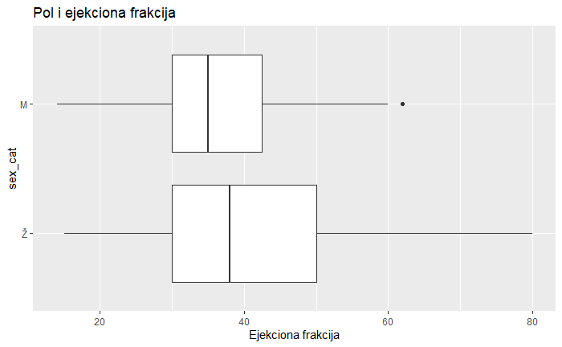

```r
ggplot(data = data, mapping = aes(x = ejection_fraction, y=sex_cat)) + geom_boxplot() + labs(title = "Pol i ejekciona frakcija", x = "Ejekciona frakcija")
```

Vidimo da osobe ženskog pola iz našeg skupa podataka imaju višu ejekcionu frakciju.

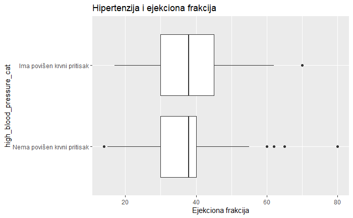

```r
ggplot(data = data, mapping = aes(x = ejection_fraction, y=high_blood_pressure_cat)) + geom_boxplot() + labs(title = "Hipertenzija i ejekciona frakcija", x = "Ejekciona frakcija")
```

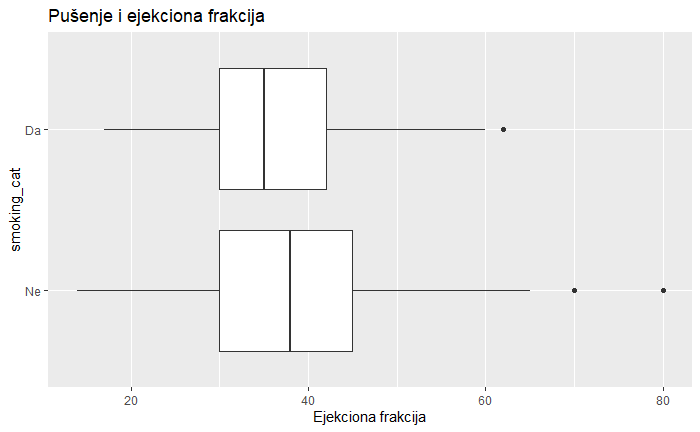

```r
ggplot(data = data, mapping = aes(x = ejection_fraction, y=smoking_cat)) + geom_boxplot() + labs(title = "Pušenje i ejekciona frakcija", x = "Ejekciona frakcija")
```

Odavde možemo zaključiti da nepušači imaju višu ejekcionu frakciju.

Iskoristićemo atribute pol i pušenje da odredimo najbolju moguću vrednost kojom ćemo zameniti nedostajuću. Ispitanik kome nedostaje vrednost za ejekcionu frakciju je muškog pola i nije pušac. Pronaći ćemo njemu slične ispitanike.

```r
similar_respondents_ef=data[which(data$sex==1 & data$smoking==0 & !is.na(data$ejection_fraction)),]
similar_respondents_ef
```

|  | age | anaemia | creatinine_phosphokinase | diabetes | ejection_fraction | high_blood_pressure | platelets | serum_creatinine | serum_sodium | sex | smoking | time | DEATH_EVENT | anaemia_cat | diabetes_cat | high_blood_pressure_cat | sex_cat | smoking_cat | DEATH_EVENT_cat | age_cat |
| --- | --- | --- | --- | --- | --- | --- | --- | --- | --- | --- | --- | --- | --- | --- | --- | --- | --- | --- | --- | --- |
| 1 | 75 | 0 | 582 | 0 | 20 | 1 | 265000 | 1.90 | 130 | 1 | 0 | 4 | 1 | Nema anemiju | Nema dijabetes | Ima povišen krvni pritisak | M | Ne | Preminuo | 66-75 |
| 2 | 55 | 0 | 7861 | 0 | 38 | 0 | 263358 | 1.10 | 136 | 1 | 0 | 6 | 1 | Nema anemiju | Nema dijabetes | Nema povišen krvni pritisak | M | Ne | Preminuo | 51-65 |
| 4 | 50 | 1 | 111 | 0 | 20 | 0 | 210000 | 1.90 | 137 | 1 | 0 | 7 | 1 | Ima anemiju | Nema dijabetes | Nema povišen krvni pritisak | M | Ne | Preminuo | 40-50 |
| 7 | 75 | 1 | 246 | 0 | 15 | 0 | 127000 | 1.20 | 137 | 1 | 0 | 10 | 1 | Ima anemiju | Nema dijabetes | Nema povišen krvni pritisak | M | Ne | Preminuo | 66-75 |
| 13 | 45 | 1 | 981 | 0 | 30 | 0 | 136000 | 1.10 | 137 | 1 | 0 | 11 | 1 | Ima anemiju | Nema dijabetes | Nema povišen krvni pritisak | M | Ne | Preminuo | 40-50 |
| 14 | 50 | 1 | 168 | 0 | 38 | 1 | 276000 | 1.10 | 137 | 1 | 0 | 11 | 1 | Ima anemiju | Nema dijabetes | Ima povišen krvni pritisak | M | Ne | Preminuo | 40-50 |
| 16 | 82 | 1 | 379 | 0 | 50 | 0 | 47000 | 1.30 | 136 | 1 | 0 | 13 | 1 | Ima anemiju | Nema dijabetes | Nema povišen krvni pritisak | M | Ne | Preminuo | 75+ |
| 17 | 87 | 1 | 149 | 0 | 38 | 0 | 262000 | 0.90 | 140 | 1 | 0 | 14 | 1 | Ima anemiju | Nema dijabetes | Nema povišen krvni pritisak | M | Ne | Preminuo | 75+ |
| 18 | 45 | 0 | 582 | 0 | 14 | 0 | 166000 | 0.80 | 127 | 1 | 0 | 14 | 1 | Nema anemiju | Nema dijabetes | Nema povišen krvni pritisak | M | Ne | Preminuo | 40-50 |
| 24 | 53 | 0 | 63 | 1 | 60 | 0 | 368000 | 0.80 | 135 | 1 | 0 | 22 | 0 | Nema anemiju | Ima dijabetes | Nema povišen krvni pritisak | M | Ne | Nije preminuo | 51-65 |

[output cut: 97 more lines]

Sada kada imamo ispitanike sa sličnim osobinama, proverićemo distribuciju podataka.

```r
shapiro.test(similar_respondents_ef$ejection_fraction)
```

```
    Shapiro-Wilk normality test

data:  similar_respondents_ef$ejection_fraction
W = 0.95377, p-value = 0.00094
```

Kako je p-value ispod 0.05, to znači da ćemo i ovog puta iskoristiti median.

```r
as.integer(median(similar_respondents_ef$ejection_fraction))
```

```
[1] 38
```

```r
ef_median = as.integer(median(similar_respondents_ef$ejection_fraction))
```

Zamenićemo NA sa ovom vrednošću:

```r
data$ejection_fraction[is.na(data$ejection_fraction)] = ef_median
```

Provera:

```r
length(which(is.na(data$ejection_fraction)))
```

```
[1] 0
```

### Kreatinin

```r
length(which(is.na(data$serum_creatinine)))
```

```
[1] 3
```

Imamo tri vrste sa nedostajućim vrednostima za kreatinin.

```r
data[which(is.na(data$serum_creatinine)),]
```

|  | age | anaemia | creatinine_phosphokinase | diabetes | ejection_fraction | high_blood_pressure | platelets | serum_creatinine | serum_sodium | sex | smoking | time | DEATH_EVENT | anaemia_cat | diabetes_cat | high_blood_pressure_cat | sex_cat | smoking_cat | DEATH_EVENT_cat | age_cat |
| --- | --- | --- | --- | --- | --- | --- | --- | --- | --- | --- | --- | --- | --- | --- | --- | --- | --- | --- | --- | --- |
| 309 | 45 | 0 | 7702 | 1 | 25 | 1 | 390000 | NA | 139 | 1 | 0 | 60 | 1 | Nema anemiju | Ima dijabetes | Ima povišen krvni pritisak | M | Ne | Preminuo | 40-50 |
| 310 | 40 | 0 | 582 | 1 | 38 | 1 | 263358 | NA | 137 | 0 | 0 | 185 | 0 | Nema anemiju | Ima dijabetes | Ima povišen krvni pritisak | Ž | Ne | Nije preminuo | 40-50 |
| 314 | 61 | 1 | 95 | 0 | 60 | 0 | 337000 | NA | 135 | 1 | 1 | 146 | 0 | Ima anemiju | Nema dijabetes | Nema povišen krvni pritisak | M | Da | Nije preminuo | 51-65 |

```r
which(is.na(data$serum_creatinine))
```

```
[1] 307 308 312
```

Iz domenskog znanja, poznato nam je da na nivoe kreatinina u krvi mogu da utiču starost i pol ispitanika, da li ima anemiju, da li je dijabetičar, da li pati od visokog krvnog pritiska i da li je pušač.

U prethodno prikazanim redovima, vidimo da se radi o dve muške osobe i jednoj ženskoj. Muške osobe su u različitim starosnim grupama pa ćemo i za njih posebno morati da računamo vrednost kojom ćemo zameniti nedostajuću.

```r
scf = data[which(data$sex_cat=="Ž" & data$age_cat=="40-50" & data$anaemia==0 & data$diabetes==1 & data$high_blood_pressure==1 & data$smoking==0 & !is.na(data$serum_creatinine)),]
```

Sada ćemo **Šapirovim testom normalnosti** odrediti da li je raspodela podataka normalna ili ne. Na taj način utvrdjujemo da li za nedostajuću vrednost uzimamo **mean** ili **median**.

```r
shapiro.test(scf$serum_creatinine)
```

```
    Shapiro-Wilk normality test

data:  scf$serum_creatinine
W = 0.94561, p-value = 0.5505
```

Kako je vrednost p veća od praga 0.05, zaključujemo da je raspodela normalna pa ćemo koristiti mean vrednost za popunjavaje nedostajuće kod ženskog ispitanika.

```r
scfmean=mean(scf$serum_creatinine)
data$serum_creatinine[308] = scfmean
data[308,]
```

|  | age | anaemia | creatinine_phosphokinase | diabetes | ejection_fraction | high_blood_pressure | platelets | serum_creatinine | serum_sodium | sex | smoking | time | DEATH_EVENT | anaemia_cat | diabetes_cat | high_blood_pressure_cat | sex_cat | smoking_cat | DEATH_EVENT_cat | age_cat |
| --- | --- | --- | --- | --- | --- | --- | --- | --- | --- | --- | --- | --- | --- | --- | --- | --- | --- | --- | --- | --- |
| 310 | 40 | 0 | 582 | 1 | 38 | 1 | 263358 | 1.36 | 137 | 0 | 0 | 185 | 0 | Nema anemiju | Ima dijabetes | Ima povišen krvni pritisak | Ž | Ne | Nije preminuo | 40-50 |

Isti postupak ponavljamo za preostala dva ispitanika.

```r
scm1 = data[which(data$sex_cat=="M" & data$age_cat=="40-50" & data$anaemia==0 & data$diabetes==1 & data$high_blood_pressure==1 & data$smoking==0 & !is.na(data$serum_creatinine)),]
```

```r
shapiro.test(scm1$serum_creatinine)
```

```
    Shapiro-Wilk normality test

data:  scm1$serum_creatinine
W = 0.75, p-value < 2.2e-16
```

```r
scm1mean=mean(scm1$serum_creatinine)
data$serum_creatinine[307] = scm1mean
data[307,]
```

|  | age | anaemia | creatinine_phosphokinase | diabetes | ejection_fraction | high_blood_pressure | platelets | serum_creatinine | serum_sodium | sex | smoking | time | DEATH_EVENT | anaemia_cat | diabetes_cat | high_blood_pressure_cat | sex_cat | smoking_cat | DEATH_EVENT_cat | age_cat |
| --- | --- | --- | --- | --- | --- | --- | --- | --- | --- | --- | --- | --- | --- | --- | --- | --- | --- | --- | --- | --- |
| 309 | 45 | 0 | 7702 | 1 | 25 | 1 | 390000 | 0.9 | 139 | 1 | 0 | 60 | 1 | Nema anemiju | Ima dijabetes | Ima povišen krvni pritisak | M | Ne | Preminuo | 40-50 |

```r
scm2 = data[which(data$sex_cat=="M" & data$age_cat=="51-65" & data$anaemia==1 & data$diabetes==0 & data$high_blood_pressure==0 & data$smoking==1 & !is.na(data$serum_creatinine)),]
```

```r
shapiro.test(scm2$serum_creatinine)
```

```
    Shapiro-Wilk normality test

data:  scm2$serum_creatinine
W = 0.95543, p-value = 0.7495
```

```r
scm2mean=mean(scm2$serum_creatinine)
data$serum_creatinine[312] = scm2mean
data[312,]
```

|  | age | anaemia | creatinine_phosphokinase | diabetes | ejection_fraction | high_blood_pressure | platelets | serum_creatinine | serum_sodium | sex | smoking | time | DEATH_EVENT | anaemia_cat | diabetes_cat | high_blood_pressure_cat | sex_cat | smoking_cat | DEATH_EVENT_cat | age_cat |
| --- | --- | --- | --- | --- | --- | --- | --- | --- | --- | --- | --- | --- | --- | --- | --- | --- | --- | --- | --- | --- |
| 314 | 61 | 1 | 95 | 0 | 60 | 0 | 337000 | 1.042222 | 135 | 1 | 1 | 146 | 0 | Ima anemiju | Nema dijabetes | Nema povišen krvni pritisak | M | Da | Nije preminuo | 51-65 |

Prikazaćemo grafik nakon hendlovanja NA vrednosti:

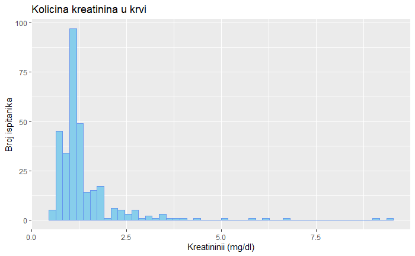

```r
ggplot(data=data) +
  geom_histogram(aes(x=serum_creatinine), bins=50,fill = "skyblue", color = "cornflowerblue")+
  labs(title = "Količina kreatinina u krvi",
       x = "Kreatininii (mg/dl)",
       y = "Broj ispitanika")
```

S obzirom da nismo imali veliki broj NA, samim tim nismo dodali mnogo vrednosti koje bi mogle da naruše raspodelu i raznovrsnost podataka za ovaj parametar.

```r
sapply(data, function(x) sum(is.na(x)))
```

```
                     age                  anaemia creatinine_phosphokinase                 diabetes
                       0                        0                        0                        0
       ejection_fraction      high_blood_pressure                platelets         serum_creatinine
                       0                        0                        0                        0
            serum_sodium                      sex                  smoking                     time
                       0                        0                        0                        0
             DEATH_EVENT              anaemia_cat             diabetes_cat  high_blood_pressure_cat
                       0                        0                        0                        0
                 sex_cat              smoking_cat          DEATH_EVENT_cat                  age_cat
                       0                        0                        0                        0
```

# Izuzeci

### Starost

```r
summary(data$age)
```

```
   Min. 1st Qu.  Median    Mean 3rd Qu.    Max.
  40.00   50.00   60.00   60.72   70.00   95.00
```

Minimum i maksimum vrednosti za godine ispitanika nam govori da u skupu podataka najverovatnije nemamo odstupanja koja bi mogla uticati na kvalitet predviđanja, ali to možemo proveriti i grafički. Boxplot predstavlja dobar izbor jer na njemu lako možemo detektovati netipične vrednosti.

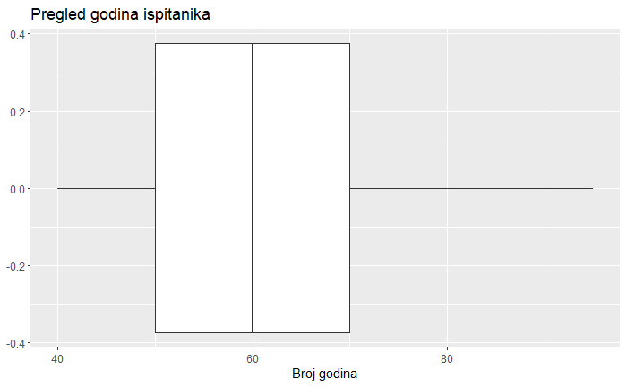

```r
ggplot(data = data, mapping = aes(x = age)) + geom_boxplot() + labs(title = "Pregled godina ispitanika", x = "Broj godina")
```

Zaključujemo da nema netipičnih vrednosti za starost.

### CPK enzim u krvi

Na osnovu domenskog znanja, normalne vrednosti ovog enzima u krvi iznose **između 10 i 120 mcg/L**. Sve preko toga smatra se povišenim, a rezultati koji prelaze **5000 mcg/L** smatraju se zabrinjavajućim. Povišen nivo ovog enzima u krvi može, između ostalog, biti indikator srčanih problema i potencijalnog otkaza srca koji predviđamo.  
Prisetimo se rasporeda vrednosti ovog enzima u skupu podataka:

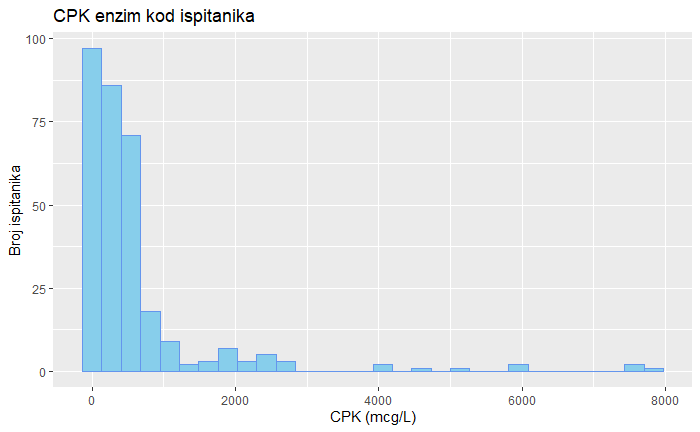

```r
ggplot(data = data, mapping = aes(x = creatinine_phosphokinase)) + geom_histogram(fill="skyblue", color="cornflowerblue", bins = 30) + labs(title = "CPK enzim kod ispitanika", x = "CPK (mcg/L)", y = "Broj ispitanika")
```

Vrednosti preko 4000 mcg/L mogu na prvi pogled delovati kao outlier-i, ali su i takve vrednosti moguće ukoliko npr. ispitanici imaju neku povredu.

Kreatin kinaza (CPK) zavisi od starosti i pola ispitanika.

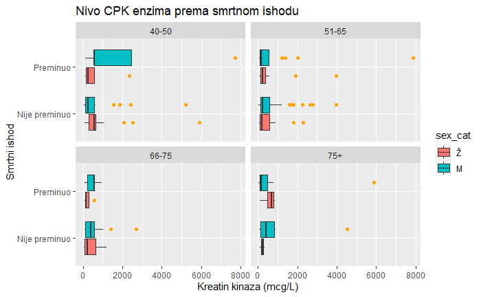

```r
ggplot(data, aes(x = creatinine_phosphokinase, y = DEATH_EVENT_cat, fill = sex_cat)) +
  geom_boxplot(outlier.colour = "orange") +
  labs(title = "Nivo CPK enzima prema smrtnom ishodu", x = "Kreatin kinaza (mcg/L)", y = "Smrtni ishod")+
  facet_wrap(~age_cat,nrow = 2)
```

Možemo primetiti da za najveći broj ispitanika kreatin kinaza ne prelazi 1000 mcg/L. Kao što je već napomenuto, sve vrednosti preko 120 mcg/L predstavljaju povišen nivo ovog enzima. Svaka povreda ili oštećenje mozga, srca ili skeletnih mišića može da izazove povišen CPK, samim tim razlozi za povišen CPK kod ispitanika mogu varirati. Najčešći slučaj u realnosti je da se dogodila povreda mišićnog tkiva. Sa grafika možemo očitati i neke jako visoke vrednosti kreatin kinaze koje boxplot detektuje kao outlier-e, ali kako one nisu nemoguće, nećemo ih smatrati netipičnim.